# Project: Investigate show/No show appointment Dataset

# What about hypertension?

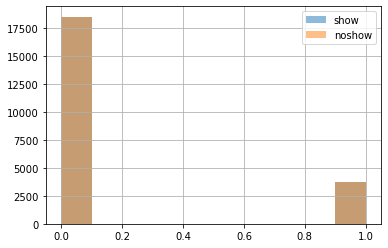

```python
df.Hipertension[show].hist(alpha=0.5,label='show')
df.Hipertension[noshow].hist(alpha=0.5,label='noshow')
plt.legend();
```

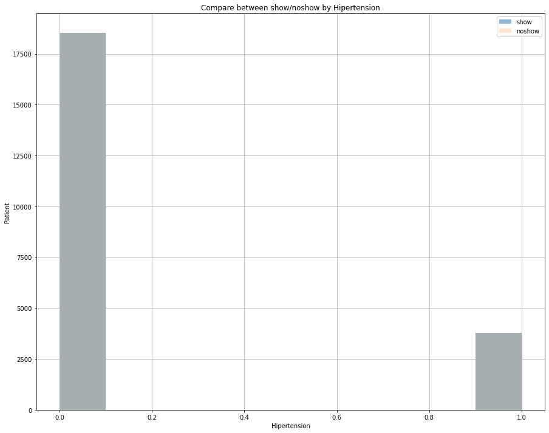

```python
plt.figure(figsize=[15,12])
df.Hipertension[show].hist(alpha=0.5, label ='show')
df.Hipertension[noshow].hist(alpha=0.2, label ='noshow')
plt.legend();
plt.title('Compare between show/noshow by Hipertension')
plt.xlabel('Hipertension')
plt.ylabel('Patient')
```

There is no somThing clear to Compare

# what the most group age showed up?

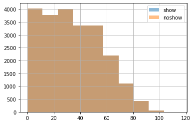

```python
df.Age[show].hist(alpha=0.5,label='show')
df.Age[noshow].hist(alpha=0.5,label='noshow')
plt.legend();
```

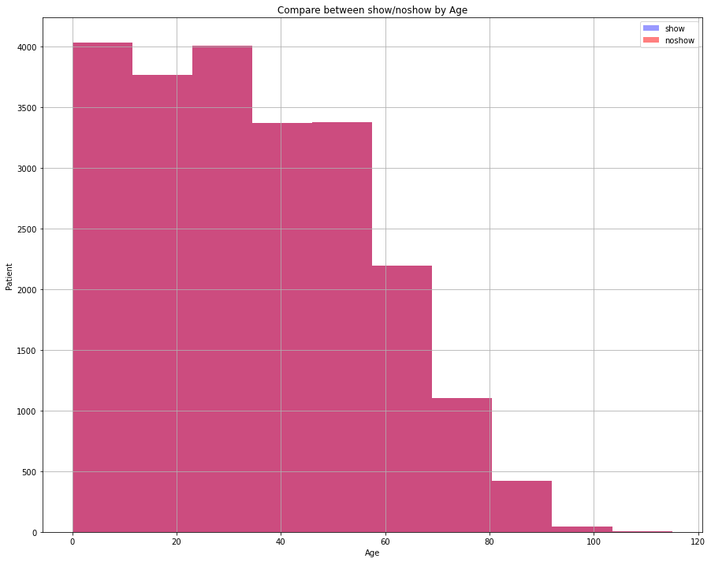

```python
plt.figure(figsize=[15,12])
df.Age[show].hist(alpha=0.4,color='blue' ,label ='show')
df.Age[noshow].hist(alpha=0.5,color='red' ,label ='noshow')
plt.legend()
plt.title('Compare between show/noshow by Age')
plt.xlabel('Age')
plt.ylabel('Patient');
```

The most age showed up is from 0-10 years

# did who Received SMS showed up?

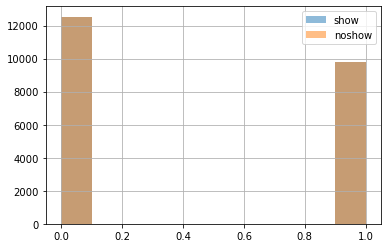

```python
df.SMS_received[show].hist(alpha=0.5,label='show')
df.SMS_received[noshow].hist(alpha=0.5,label='noshow')
plt.legend();
```

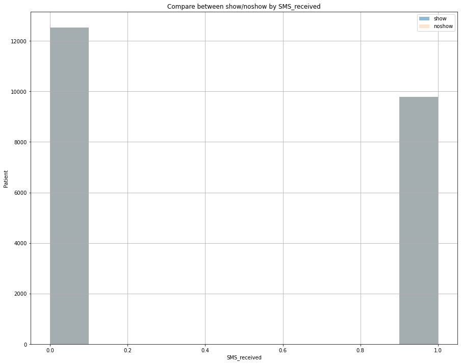

```python
plt.figure(figsize=[15,12])
df.SMS_received[show].hist(alpha=0.5, label ='show')
df.SMS_received[noshow].hist(alpha=0.2, label ='noshow')
plt.legend();
plt.title('Compare between show/noshow by SMS_received')
plt.xlabel('SMS_received')
plt.ylabel('Patient');
```

who didn't receive SMS showed more than who did

## Conclusions

in the first I install the data set then i clean it by drop what i dont want and Rename No-show to No_show and theres no null ,I but for who showed -NO- and for noshowed -Yes- the information that i get is

-The most age showed up is from 0-10 years

-who didn't receive SMS showed more than who did

## Imitation

the dataset Showed ther -1 year old and thats not normal

Spelling mistakes in (Hipertension) it's hypertension

it's strange that who received SMS showed less